# GSE247883

**Reanalysis of "Long non‑coding RNA lung cancer‑associated transcript 1 regulates ferroptosis via microRNA‑34a‑5p‑mediated GTP cyclohydrolase 1 downregulation in lung cancer cells." by Tai F et al., Int J Oncol, 2024**

Tai F, Zhai R, Ding K, Zhang Y, Yang H, Li H, et al. Long non‑coding RNA lung cancer‑associated transcript 1 regulates ferroptosis via microRNA‑34a‑5p‑mediated GTP cyclohydrolase 1 downregulation in lung cancer cells. Int J Oncol. 2024;64(6):. PMID: 38757341

[Visit GEO accession page](https://www.ncbi.nlm.nih.gov/geo/query/acc.cgi?acc=GSE247883)

## **Abstract**

In this study, Tai F et al. [1] profiled A549 cells treated with DMSO, RSL3, or RSL3 co-treated with Fer-1 to further our understanding of ferroptosis in non-small cell lung cancer (NSCLC). The reanalysis of this dataset includes a full RNA-seq analysis pipeline. Initially, dimensionality reduction is performed using UMAP [2], PCA [3], and t-SNE [4] to visualize sample relationships. Next, a clustergram heatmap is generated to display gene expression patterns across samples. Differential gene expression analysis is then conducted for each control and perturbation sample pair. Enrichment analysis for each gene signature is carried out using Enrichr [5, 6, 7], followed by transcription factor analysis of these signatures using ChEA3 [8]. Finally, L2S2 [9] and DRUG-seqr [10] are utilized to identify potential FDA and non-FDA approved drugs that either reverse or mimic the observed gene expression signatures. The results of each step are provided as both tables and bar charts.

*This abstract was generated with the assistance of Gemini 2.0 Flash.*

## **Methods**

*RNA-seq alignment*

*Gene matrix processing*

The raw gene matrix was filtered to remove genes that do not have an average of 3 reads across the samples. It was then quantile, log2, and z-score normalized. A regex-based function was used to infer whether individual samples belong to a “control” or a “perturbation” group by processing the metadata associated with each sample.

*Dimensionality Reduction Visualization*

*Clustergram Heatmap*

As a preliminary step, the top 1000 genes exhibiting most variability were selected. Using this new set, clustergram heatmaps were generated. Two versions of the clustergram exist: an interactive one generated by Clustergrammer [13] and a publication-ready alternative.

*Differentially Expressed Genes Calculation and Volcano Plot*

Differentially expressed genes between the control and perturbation samples were calculated using Limma Voom [14]. The logFC and -log10p values of each gene were visualized as a volcano scatterplot. Upregulated and downregulated genes were selected according to this criteria: p < 0.05 and |logFC| > 1.0.

*Enrichr Enrichment Analysis*

The upregulated and down-regulated sets were separately submitted to Enrichr [5, 6, 7]. These sets were compared against libraries from ChEA [8], ARCHS4 [12], Reactome Pathways [15], MGI Mammalian Phenotype [16], Gene Ontology Biological Processes [17], GWAS Catalog [18], KEGG [19, 20, 21], and WikiPathways [22]. The top matched terms from each library and their respective -log10p values were visualized as barplots.

*Chea3 Transcription Factor Analysis*

The upregulated and down-regulated sets were separately submitted to Chea3 [8]. These sets were compared against the libraries ARCHS4 Coexpression [12], GTEx Coexpression [23], Enrichr [5, 6, 7], ENCODE ChIP-seq [24, 25], ReMap ChIP-seq [26], and Literature-mined ChIP-seq. The top matched TFs were ranked according to their average score across each library and represented as barplots.

*L2S2 and Drug-seqr drug analysis*

The top 500 up and downregulated sets were submitted simulataneously to identify reverser and mimicker molecules, both FDA and non-FDA approved, from the L2S2 [9] and Drug-seqr [10] databases. The top matched molecules were compiled into tables and visualized as barplots.

|  | GSM7902660 | GSM7902661 | GSM7902662 | GSM7902663 | GSM7902664 | GSM7902665 | GSM7902666 | GSM7902667 | GSM7902668 |
| --- | --- | --- | --- | --- | --- | --- | --- | --- | --- |
| TSPAN6 | 507 | 530 | 530 | 581 | 536 | 517 | 566 | 579 | 619 |
| TNMD | 0 | 0 | 0 | 0 | 0 | 0 | 0 | 0 | 0 |
| DPM1 | 445 | 441 | 458 | 434 | 432 | 383 | 459 | 462 | 466 |
| SCYL3 | 221 | 230 | 232 | 261 | 238 | 226 | 238 | 297 | 245 |
| C1ORF112 | 554 | 558 | 634 | 483 | 580 | 519 | 616 | 632 | 633 |

**table 1**: This is a preview of the first 5 rows of the raw RNA-seq expression matrix from GSE247883.

Download raw counts: /home/ajy20/geo2reports/public/GSE247883/raw_counts.csv

# **Results**

## **Dimensionality Reduction**

### **UMAP**

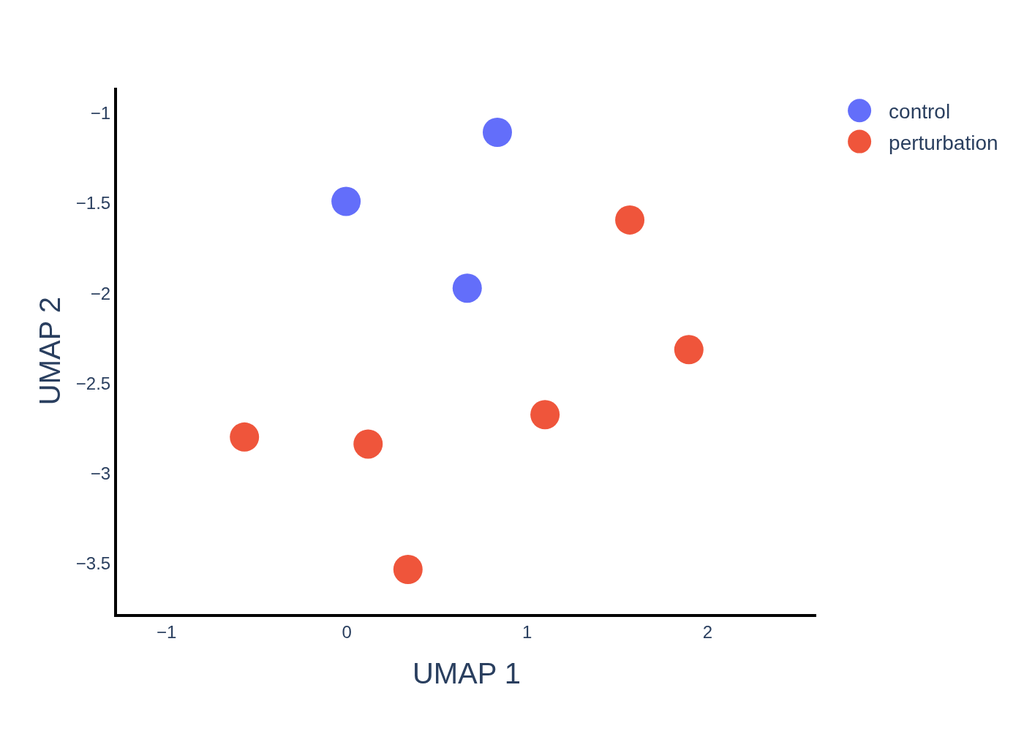

**Figure 1**: This figure displays a 2D scatter plot of a UMAP decomposition of the sample data. Each point represents an individual sample, colored by its experimental group.

Download UMAP figure as png: /home/ajy20/geo2reports/public/GSE247883/umap.png

Download UMAP figure as svg: /home/ajy20/geo2reports/public/GSE247883/umap.svg

Download UMAP figure as jpeg: /home/ajy20/geo2reports/public/GSE247883/umap.jpeg

## **Clustergram Heatmaps**

[interactive chart not shown]

**Figure 2**: The figure contains an interactive heatmap displaying gene expression for each sample in the RNA-seq dataset. Every row of the heatmap represents a gene, every column represents a sample, and every cell displays normalized gene expression values. The heatmap additionally features color bars beside each column which represent prior knowledge of each sample, such as the tissue of origin or experimental treatment.